# 01 select subsamples by UMEND depth

Holly Beale

16 May, 2019

```r
library(tidyverse); citation("tidyverse")
library(forcats); citation("forcats")
library(knitr); citation("knitr")
```

# Load data

```r
read_counts=read_tsv(
    "../data/read_counts.txt",
    col_names=c("sample_id", "measurement", "read_count"))
parent_publication_ids <- read_tsv("../data/parent_sample_data_source.tsv") %>%
  select(Eval_ID, publication_id)
```

# Groom data

```r
UMEND_read_counts <- read_counts %>%
    mutate(
        target_UMEND_count=as.numeric(gsub("^.*_est([0-9]*)M_.*$", "\\1", sample_id)),
        parent_id=gsub("_est.*$", "", sample_id),
        measurement=factor(measurement, levels=c("total_sequences",
 "Uniquely_mapped_read_count","Uniquely_mapped_non_duplicate_read_count",  "UMEND"))
        ) %>%
  filter(
        measurement =="UMEND"
    ) %>%
  select(-measurement) %>%
  rename(UMEND = read_count) %>%
  left_join(parent_publication_ids,
            by=c(parent_id="Eval_ID"))
```

# Define desired depths

```r
selected_subset_depths <- tibble(target_UMEND_count = c(1, seq(4, 48, by = 4)))
selected_subset_depths$median_of_depth_bin <- selected_subset_depths$target_UMEND_count
selected_subset_depths$median_of_depth_bin[selected_subset_depths$target_UMEND_count==1]  <- 0
```

# Find samples closest to bins

This is required since the actual number of UMEND reads in a subsample differs from the intended number of UMEND reads in the subsample

```r
closest_samples <- NULL
for (this_parent_id in parent_publication_ids$Eval_ID)  {
  for (this_target_UMEND_count in selected_subset_depths$target_UMEND_count){
    # this_parent_id="TH_Eval_016"
    # this_target_UMEND_count = 48
    closest_subsample <- UMEND_read_counts %>%
      filter(parent_id == this_parent_id) %>%
      mutate(dist_from_this_target_UMEND_count= abs(UMEND/1E6-this_target_UMEND_count )) %>%
      arrange(dist_from_this_target_UMEND_count) %>%
      top_n(-1, dist_from_this_target_UMEND_count)

    closest_samples <- bind_rows(closest_samples,
                                 tibble(parent_id=this_parent_id,
                                        target_UMEND_count=this_target_UMEND_count,
                                        closest_sample = closest_subsample$sample_id,
                                        target_UMEND_count_of_closest_sample = closest_subsample$target_UMEND_count,
                                        publication_id = closest_subsample$publication_id
                                        ))
  }
}
```

# In one case, the sample closest to the bin median isn’t the expected one.

```r
  closest_samples %>%
    filter(target_UMEND_count_of_closest_sample != target_UMEND_count)
```

```
## # A tibble: 1 x 5
##   parent_id target_UMEND_co… closest_sample target_UMEND_co… publication_id
##   <chr>                <dbl> <chr>                     <dbl> <chr>
## 1 TH_Eval_…               48 TH_Eval_016_e…               50 S3
```

## options for handling the difference between targeted UMEND count and actual UMEND count

I use the TH_Eval_016 with 50M target_UMEND_count for the 48M bin. If we used the 50M values to define True, I might be tempted to keep the samples with a target UMEND value of 48M for the 48M bin. But currently we don’t use the 50M values for anything.

A variable in which the smallest depth is zero is required to make the bin plots come out correctly. I rename the 0 bin to be 1 after the plot is generated. I use median_of_depth_bin.

A variable in which the smallest depth is one is required to make the point plots come out correctly (so that a sensitivity isn’t reported for zero reads, because that would make no sense). I use target_UMEND_count.

The values are the same in every other case. Specifically, it is the value that is common across parent samples at which these samples can be compared.

Literally, target UMEND count I had in mind when I created TH_Eval_016_est50M_UMEND_seqtk_seed_3541 was 50M, but it’s the sample from 016 with the number of UMEND reads sloest to 48, so I will use it for the 48M bin. I keep this variable name in spite of this imprecision.

# Select and write data

```r
selected_samples <- closest_samples %>%
  select(sample_id = closest_sample, target_UMEND_count,    parent_id, publication_id) %>%
  left_join(selected_subset_depths, by="target_UMEND_count") %>%
  select(-publication_id, everything() )

write_tsv(selected_samples, "../data/evenly_selected_subsamples_with_binwidth_4.tsv")
```

# Visualize targeted and actual UMEND counts

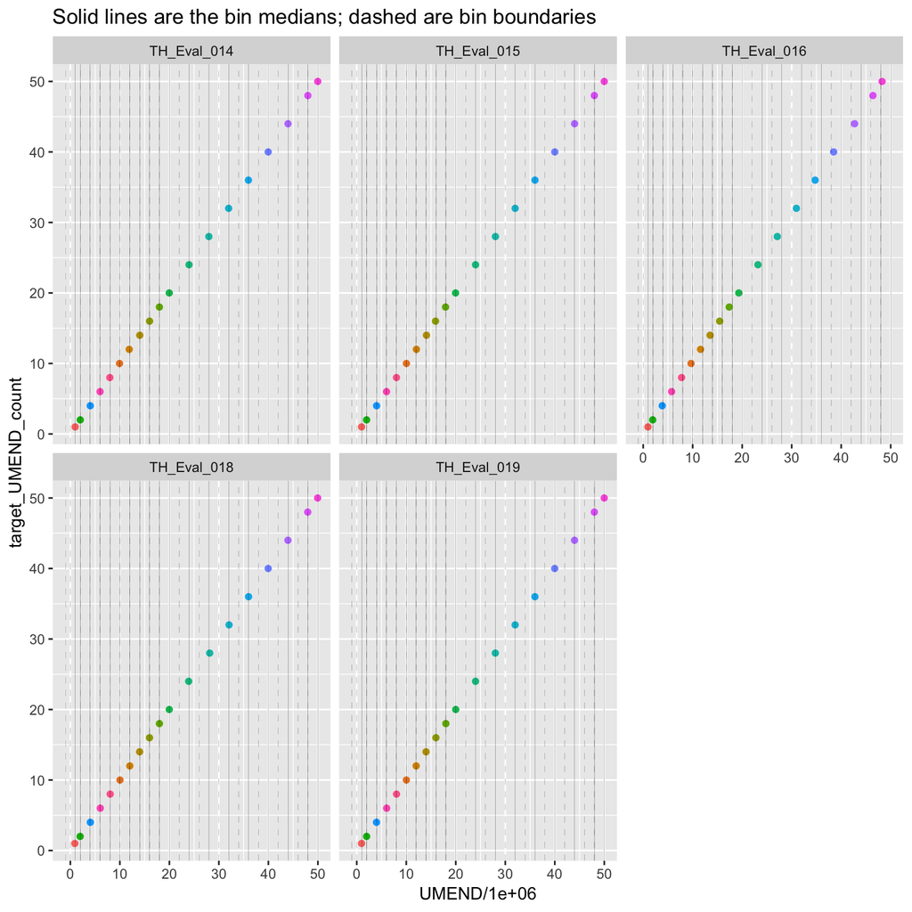

```r
ggplot(UMEND_read_counts) +
  geom_point(aes( x=UMEND/1e6, y=target_UMEND_count, color=as.character(target_UMEND_count))) +
  geom_vline(aes(xintercept=target_UMEND_count), size=0.05) +
  geom_vline(aes(xintercept=target_UMEND_count-2), linetype="dashed", size=0.05) +
  facet_wrap(~parent_id) +
  theme(legend.position="none") +
  ggtitle("Solid lines are the bin medians; dashed are bin boundaries")
```